# Worked Example: Food for Thought

Johan Larsson

Behnaz Pirzamanbein

Jonas Wallin

# 1 Budget Share of Food for Spanish Households

In this worked example, we will make use of our newfound tools to handle a big data set. We will examine household expenditure data from Spanish households in 1980. Our study’s objective is to explore how the share of the household budget spent on food relates to total expenditure and household size.

The data set is available in the Ecdat package. We also need the **hexbin** package for the hexbin plots. Start by installing these packages (if you haven’t already).

```r
# install the data and hexagonal binning packages
install.packages(c("Ecdat", "hexbin"))
```

Then load the data set directly into your workspace by calling the `data()` function as we show next.

```r
data("BudgetFood", package = "Ecdat")
```

There are 23,972 observations and six variables in this dataset:

- `wfood`: Share of total household expenditure spent on food, recorded as a proportion between 0 and 1. For example, `0.4` means 40% of total expenditure.
- `totexp`: Total expenditure of the household
- `age`: Age of reference person in the household
- `size`: Size of the household
- `town`: size of the town where the household is placed categorized into 5 groups: 1 for small towns, 5 for big ones.
- `sex`: sex of reference person (man, woman)

# 2 Wrangling

Before we start visualizing this data set, we need to format it properly. The names of the variables are fine, but the `town` variable should be formatted as an ordered factor and `age` and `size` should be formatted as integers.

```r
library(tidyverse)
library(hexbin)

budget_food <-
  BudgetFood %>%
  mutate(
    age = as.integer(age),
    size = as.integer(size),
    town = factor(town, ordered = TRUE),
  )
```

# 3 Food Budget Share and Total Expenditure

Let’s start naively, trying out a simple scatter plot of the food budget share versus total expenditure. A smaller budget share does not necessarily mean a smaller amount spent on food: the share can fall while total expenditure rises. We keep `wfood` as a proportion in the data and format the y-axis labels as percentages.

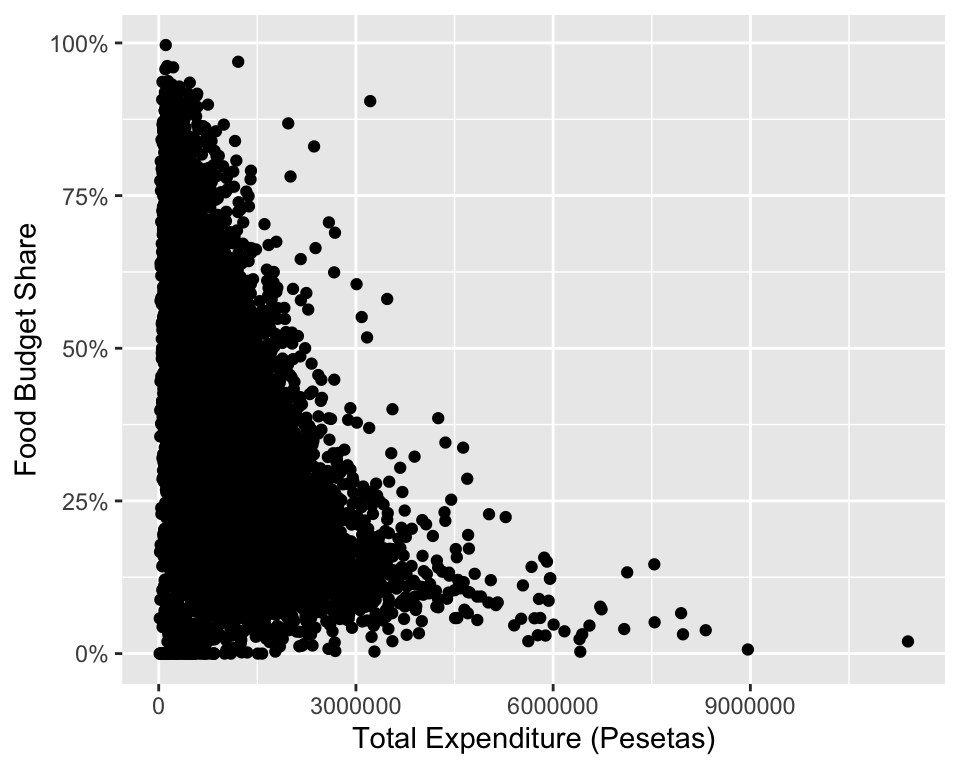

Figure 1: Food budget share versus total household expenditure

```r
ggplot(budget_food, aes(totexp, wfood)) +
  geom_point() +
  scale_y_continuous(labels = scales::label_percent()) +
  labs(x = "Total Expenditure (Pesetas)", y = "Food Budget Share")
```

Despite the large amount of overlap, we can still glean a few insights. First off, the food budget share decreases with total expenditure. This speaks to our intuition. Second, there is a number of observations that report no food expenditure whatsoever. We consider zero food expenditure implausible and therefore treat these observations as outliers. Let’s remove these observations from the data set.

```r
budget_food_cleaned <-
  budget_food %>%
  filter(wfood > 0)
```

At this point we could try to combat the overlap by reducing opacity, but another trick that is sometimes overlooked is to instead try a scale transformation. Instead of a linear scale for total expenditure, we could use a logarithmic scale.

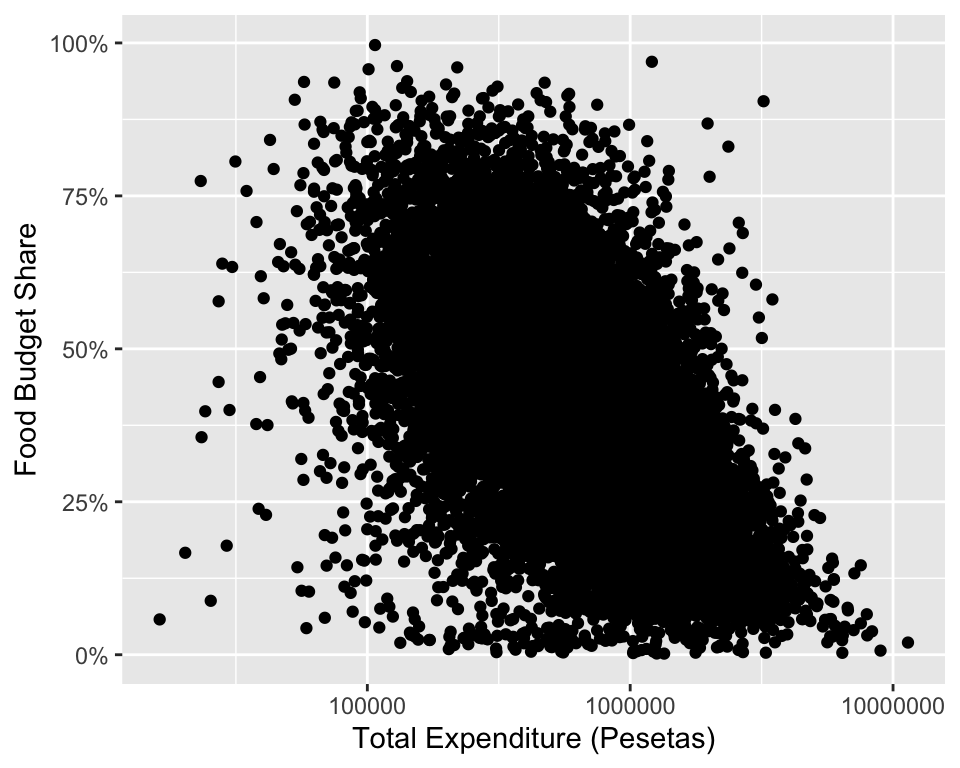

Figure 2: Food budget share versus total household expenditure, with total expenditure on a logarithmic scale

```r
ggplot(budget_food_cleaned, aes(totexp, wfood)) +
  scale_x_log10() +
  geom_point() +
  scale_y_continuous(labels = scales::label_percent()) +
  labs(x = "Total Expenditure (Pesetas)", y = "Food Budget Share")
```

Since we have learned a few new tools, let’s make use of them now. For this purpose, we are going to try a hexbin plot.

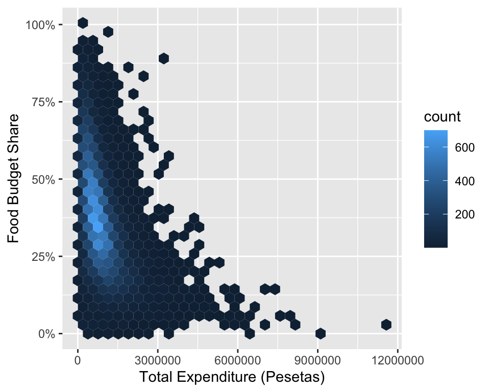

Figure 3: A hexbin plot of food budget share versus total household expenditure

```r
ggplot(budget_food_cleaned, aes(totexp, wfood)) +
  geom_hex() +
  scale_y_continuous(labels = scales::label_percent()) +
  labs(x = "Total Expenditure (Pesetas)", y = "Food Budget Share")
```

This plot definitely works better, showing the relationship in a clear fashion.

# 4 Household Size

Now that we have managed to create a plot of food budget share and total expenditure, let’s see if we can also find a relationship with the size of the household. Before we look at the complete picture, it is a good idea to first check what the overall relationship between household size and food budget share is. To do so, we first construct a boxplot.

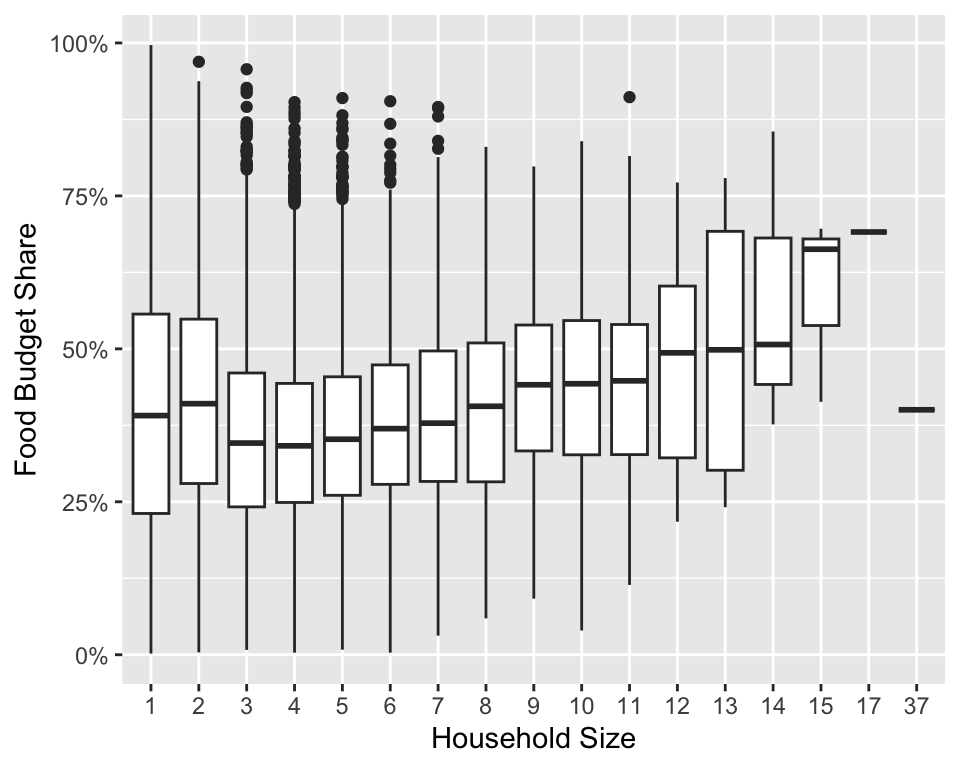

Figure 4: Food budget share by household size

```r
ggplot(budget_food_cleaned, aes(as.factor(size), wfood)) +
  geom_boxplot() +
  scale_y_continuous(labels = scales::label_percent()) +
  labs(x = "Household Size", y = "Food Budget Share")
```

In general, the food budget share tends to be higher with larger households. However, this trend does not hold for households with only one or two members. Take a minute to figure out if that makes sense to you.

Let’s return to our hexbin plot design, but now introduce household size as facets. We use fewer x-axis ticks and abbreviate millions of pesetas as `m` to keep the labels readable in the small panels.

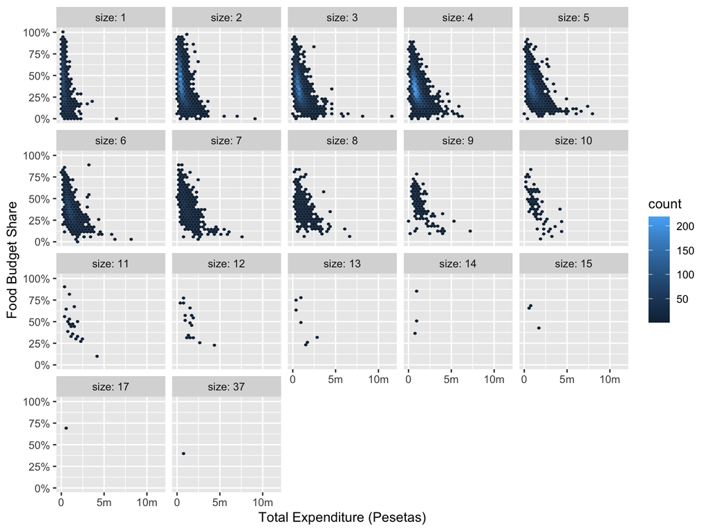

Figure 5: A hexbin plot of food budget share versus total household expenditure across household sizes

```r
ggplot(budget_food_cleaned, aes(totexp, wfood)) +
  geom_hex() +
  facet_wrap("size", labeller = labeller(size = label_both)) +
  scale_x_continuous(breaks = c(0, 5e6, 1e7), labels = c("0", "5m", "10m")) +
  scale_y_continuous(labels = scales::label_percent()) +
  labs(x = "Total Expenditure (Pesetas)", y = "Food Budget Share")
```

This plot looks promising but is crippled by the fact that some of the groups are small, which creates problems for the hexbin plot. In fact, hexbin plots can be problematic when the number of observations differs across facets. This is because all facets share the same binning scale..

To get around this problem, we are going to lump all of the households of size 6 or larger into one level, using `fct_other()`, a function from the **forcats** package. We specify the levels we want to *keep* using the `keep` argument, and all of the others are lumped together.

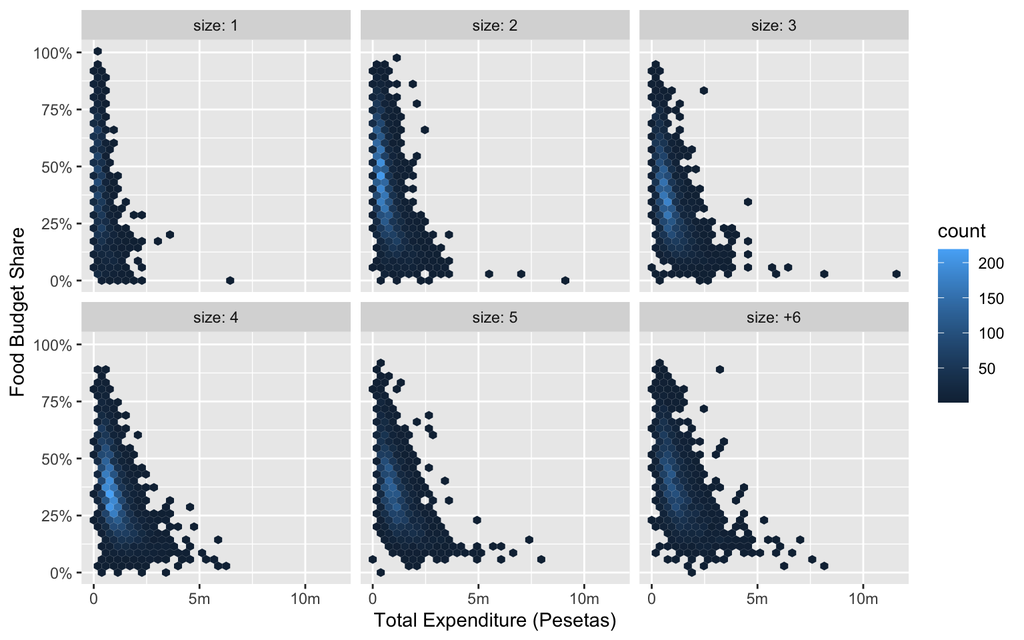

Figure 6: A hexbin plot of food budget share versus total household expenditure across household sizes. The 6+ category represents household sizes of 6 or more people.

```r
budget_food_binned <-
  budget_food_cleaned %>%
  mutate(
    size = as.factor(size),
    size = fct_other(size, keep = paste(c(1:5)), other_level = "+6")
  )

ggplot(budget_food_binned, aes(totexp, wfood)) +
  geom_hex() +
  facet_wrap("size", labeller = labeller(size = label_both)) +
  scale_x_continuous(breaks = c(0, 5e6, 1e7), labels = c("0", "5m", "10m")) +
  scale_y_continuous(labels = scales::label_percent()) +
  labs(x = "Total Expenditure (Pesetas)", y = "Food Budget Share")
```

This is now starting to look quite interesting.

# 5 Smoothers

As an alternative to the hexbin plots, we could instead use a smoother to look at the relationship between total expenditure and food budget share.

Smoothers help us see how the food budget share varies with total expenditure, including relationships that are not straight lines. They describe associations; they do not establish a causal relationship. Where observations are sparse, the fitted curve can be unstable.

Let’s try a LOESS smoother, which fits local polynomial regressions rather than one global curve. The default version uses weighted least squares. Later, we will compare it with a robust version.

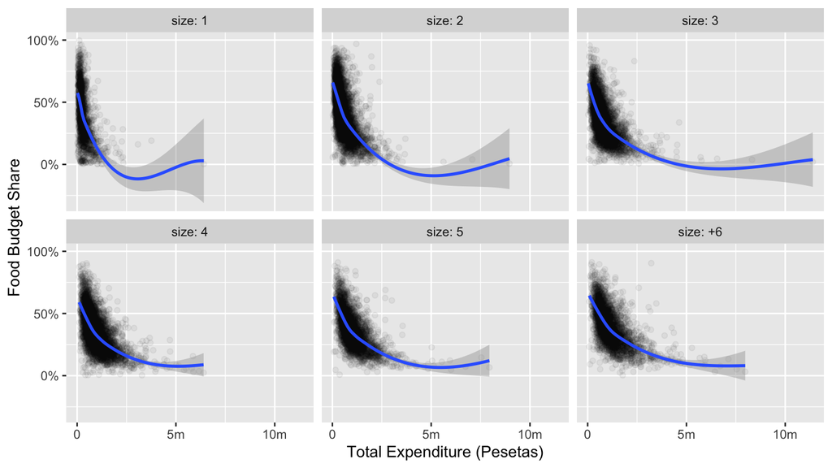

Figure 7: Food budget share versus total household expenditure, faceted by household size. A LOESS smoother, including approximate 95% confidence intervals, is used.

```r
ggplot(budget_food_binned, aes(totexp, wfood)) +
  geom_point(alpha = 0.05) +
  geom_smooth(method = "loess") +
  facet_wrap("size", labeller = labeller(size = label_both)) +
  scale_x_continuous(breaks = c(0, 5e6, 1e7), labels = c("0", "5m", "10m")) +
  scale_y_continuous(labels = scales::label_percent()) +
  labs(x = "Total Expenditure (Pesetas)", y = "Food Budget Share")
```

The problem with this plot is that the smoothers are clearly inappropriate for the extreme values of total expenditure. To work around this problem, we can create a separate data set for use exclusively in the `geom_smooth()` function.

To do so, we create a new data set, first grouping by the variable we are faceting on, `size`, and then filtering the data set to include only observations of `totexp` (total expenditure) that are large than the 0.05 quantile and smaller than the 0.95 quantile.

We then use this data in the `data` argument to `geom_smooth()` function.

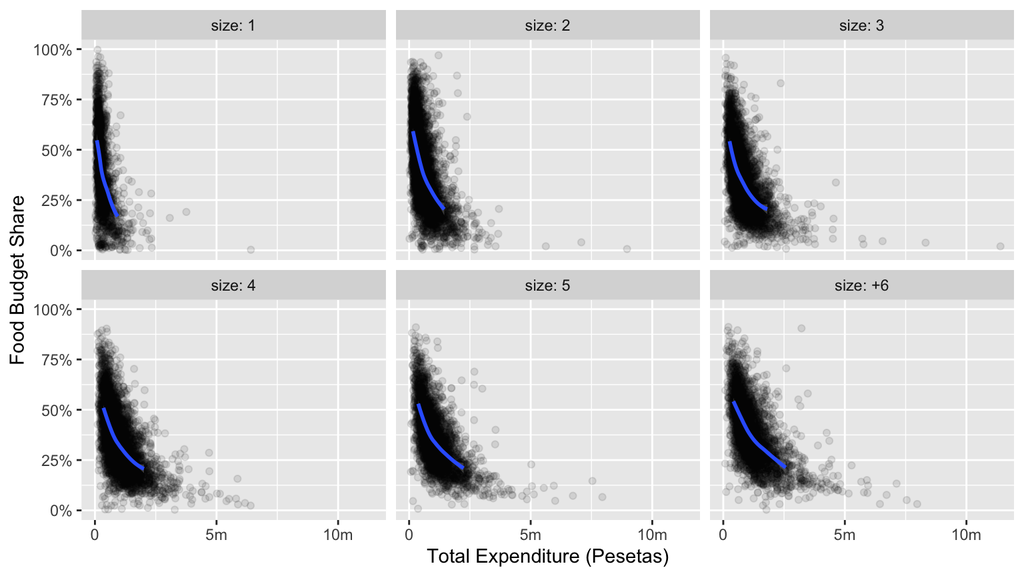

Figure 8: Food budget share versus total household expenditure, with LOESS smoothers fitted to the central 90% of total expenditure within each household-size group

```r
budget_food_smoother_data <-
  budget_food_binned %>%
  group_by(size) %>%
  filter(totexp > quantile(totexp, 0.05) & totexp < quantile(totexp, 0.95))

ggplot(budget_food_binned, aes(totexp, wfood)) +
  geom_point(alpha = 0.1) +
  geom_smooth(method = "loess", data = budget_food_smoother_data) +
  facet_wrap("size", labeller = labeller(size = label_both)) +
  scale_x_continuous(breaks = c(0, 5e6, 1e7), labels = c("0", "5m", "10m")) +
  scale_y_continuous(labels = scales::label_percent()) +
  labs(x = "Total Expenditure (Pesetas)", y = "Food Budget Share")
```

Go ahead and see if you can figure out ways to further improve this plot. Consider using the scale transformation we touch on earlier, and explore how it works together with the smoothers and hex binning.

# 6 Robust LOESS and the x Scale

The previous example refits each smoother using only the central 90% of total expenditure within its household-size group. The percentile cutoffs are an illustrative choice, and they differ between groups. Can we improve the curves without this additional filtering? We will continue using `budget_food_binned`, so the zero food shares removed earlier are still excluded.

Ordinary LOESS gives greater weight to observations close to the current x-position. A robust version also downweights observations with large residuals, using `family = "symmetric"`. This can reduce the influence of unusual food shares, but does not by itself solve problems caused by sparse observations at high total expenditure.

Let’s compare ordinary and robust LOESS, fitting to either total expenditure or its logarithm. We use one-person households to make the differences easier to see, and omit confidence bands to focus on the fitted curves.

First, define a helper that adds one LOESS curve. Its `formula` selects the original or logarithmic predictor, and `family = "symmetric"` selects robust fitting. The shared settings keep the same span and prediction grid for all four curves.

```r
loess_curve <- function(label, formula, family = "gaussian") {
  geom_smooth(
    aes(colour = label, linetype = label),
    method = "loess",
    formula = formula,
    method.args = list(family = family),
    span = 0.75,
    n = 300,
    se = FALSE,
    linewidth = 0.9
  )
}

loess_colours <- c(
  "Ordinary: original x" = "orange",
  "Robust: original x" = "purple",
  "Ordinary: log10(x)" = "blue",
  "Robust: log10(x)" = "darkgreen"
)
```

We can now add the four curves directly to the plot. The formulas determine how each model is fitted; `coord_transform()` makes their display axes logarithmic after fitting. Thus, the models using `y ~ log10(x)` determine local neighbourhoods in log expenditure, while those using `y ~ x` use the original expenditure scale.

In R, `log(x)` is the natural logarithm (base e), while `log10(x)` uses base 10. We use `log10()` to match the display axis: each tenfold increase is one log unit. Changing the base only rescales the log predictor by a constant factor, so using `log()` instead gives the same LOESS curves up to numerical rounding in this example.

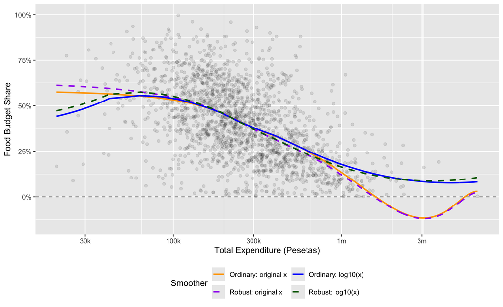

```r
food_one_person <- filter(budget_food_binned, size == "1")

ggplot(food_one_person, aes(totexp, wfood)) +
  geom_point(alpha = 0.1) +
  geom_hline(yintercept = 0, linetype = "dashed", colour = "grey50") +
  loess_curve("Ordinary: original x", y ~ x) +
  loess_curve("Robust: original x", y ~ x, family = "symmetric") +
  loess_curve("Ordinary: log10(x)", y ~ log10(x)) +
  loess_curve("Robust: log10(x)", y ~ log10(x), family = "symmetric") +
  scale_x_continuous(breaks = c(3e4, 1e5, 3e5, 1e6, 3e6),
                     labels = c("30k", "100k", "300k", "1m", "3m")) +
  scale_y_continuous(labels = scales::label_percent()) +
  scale_colour_manual(values = loess_colours, limits = names(loess_colours)) +
  scale_linetype_manual(values = c("solid", "dashed", "solid", "dashed"),
                        limits = names(loess_colours)) +
  coord_transform(x = "log10", ylim = c(-0.15, 1)) +
  labs(x = "Total Expenditure (Pesetas)", y = "Food Budget Share",
       colour = "Smoother", linetype = "Smoother") +
  guides(colour = guide_legend(nrow = 2), linetype = guide_legend(nrow = 2)) +
  theme(legend.position = "bottom")
```

On the original x-scale, both ordinary and robust LOESS give negative fitted food shares in the upper expenditure range. Fitting to log expenditure helps much more in this example than changing to robust LOESS alone. This does not guarantee reliable behaviour in sparse regions, and neither version of LOESS is constrained to stay between 0 and 1.

For details, see the documentation for [`loess()`](https://stat.ethz.ch/R-manual/R-devel/library/stats/html/loess.html).

# 7 Source Code

The source code for this document is available at https://github.com/stat-lu/dataviz/blob/main/worked-examples/food-for-thought.Rmd .